# IODS course project

Chang Rajani

# Introduction to Open Data Science - Course Project

# About the project

*Write a short description about the course and add a link to your GitHub repository here. This is an R Markdown (.Rmd) file so you should use R Markdown syntax.*

I look forward to learning a lot about R and data science.

my link is https://coolnesss.github.io/IODS-project/

```r
# This is a so-called "R chunk" where you can write R code.

date()
```

```
## [1] "Fri Nov 26 13:09:41 2021"
```

The text continues here.

# Chapter 2 student data

*Describe the work you have done this week and summarize your learning.*

- Describe your work and results clearly.
- Assume the reader has an introductory course level understanding of writing and reading R code as well as statistical methods.
- Assume the reader has no previous knowledge of your data or the more advanced methods you are using.

```r
date()
```

```
## [1] "Fri Nov 26 13:09:41 2021"
```

Lets start by reading the data

```r
analysis = read.csv('data/data.csv', header = TRUE)
print(str(analysis))
```

```
## 'data.frame':    166 obs. of  7 variables:
##  $ Age     : int  53 55 49 53 49 38 50 37 37 42 ...
##  $ gender  : chr  "F" "M" "F" "M" ...
##  $ Attitude: int  37 31 25 35 37 38 35 29 38 21 ...
##  $ Points  : int  25 12 24 10 22 21 21 31 24 26 ...
##  $ stra    : num  3.38 2.75 3.62 3.12 3.62 ...
##  $ deep    : num  3.58 2.92 3.5 3.5 3.67 ...
##  $ surf    : num  2.58 3.17 2.25 2.25 2.83 ...
## NULL
```

The data contains student questionnaire answers and attributes such as gender, age, etc. The variables describe their aptitudes, strengths and weaknesses, such as organization, reading styles, study styles, etc.

```r
library(GGally)
```

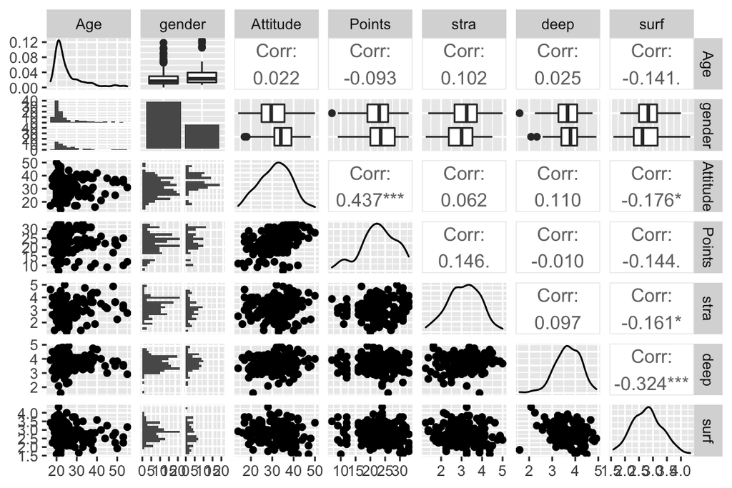

```r
library(ggplot2)

ggpairs(analysis, mapping = aes(), lower = list(combo = wrap("facethist", bins = 20)))
```

The pairwise plot indicates that for example gender has little effect on Points, with the correlation also being small. On the other hand there is a large correlation between Points and Attitude which seems to suggest that people who were motivated to study got more points in the exam. The age distribution is highly skewed, with most respondents being close to the age of 20. Otherwise, most of the other columns roughly follow a Gaussian distribution.

Lets choose the following three attributes to fit our regression model on: Attitude, Age and Gender. In other words we are interested in knowing if we can explain the exam points using these three variables.

```r
linear_regression = lm(Points ~ Age+Attitude+gender, data = analysis)
summary(linear_regression)
```

```
##
## Call:
## lm(formula = Points ~ Age + Attitude + gender, data = analysis)
##
## Residuals:
##      Min       1Q   Median       3Q      Max
## -17.4590  -3.3221   0.2186   4.0247  10.4632
##
## Coefficients:
##             Estimate Std. Error t value Pr(>|t|)
## (Intercept) 13.42910    2.29043   5.863 2.48e-08 ***
## Age         -0.07586    0.05367  -1.414    0.159
## Attitude     0.36066    0.05932   6.080 8.34e-09 ***
## genderM     -0.33054    0.91934  -0.360    0.720
## ---
## Signif. codes:  0 '***' 0.001 '**' 0.01 '*' 0.05 '.' 0.1 ' ' 1
##
## Residual standard error: 5.315 on 162 degrees of freedom
## Multiple R-squared:  0.2018, Adjusted R-squared:  0.187
## F-statistic: 13.65 on 3 and 162 DF,  p-value: 5.536e-08
```

Seeing that age and gender are not reliable predictors of exam scores, lets remove them from the model and try again with only attitude as the predictor.

```r
linear_regression = lm(Points ~ Attitude, data = analysis)
summary(linear_regression)
```

```
##
## Call:
## lm(formula = Points ~ Attitude, data = analysis)
##
## Residuals:
##      Min       1Q   Median       3Q      Max
## -16.9763  -3.2119   0.4339   4.1534  10.6645
##
## Coefficients:
##             Estimate Std. Error t value Pr(>|t|)
## (Intercept) 11.63715    1.83035   6.358 1.95e-09 ***
## Attitude     0.35255    0.05674   6.214 4.12e-09 ***
## ---
## Signif. codes:  0 '***' 0.001 '**' 0.01 '*' 0.05 '.' 0.1 ' ' 1
##
## Residual standard error: 5.32 on 164 degrees of freedom
## Multiple R-squared:  0.1906, Adjusted R-squared:  0.1856
## F-statistic: 38.61 on 1 and 164 DF,  p-value: 4.119e-09
```

Now we can see that attitude is indeed a strong predictor of exam points and this result is statistically significant, i.e unlikely to be attributed to chance.

Finally lets interpret the multiple R-squared statistic of the model. An R-squared of only 0.19 means that only 19% of the data fit the model. Importantly, after taking out the two variables Age and Gender, our R-squared dropped by only 0.01 meaning they did not contribute much to fitting the data.

We also need to visualize the model using plots.

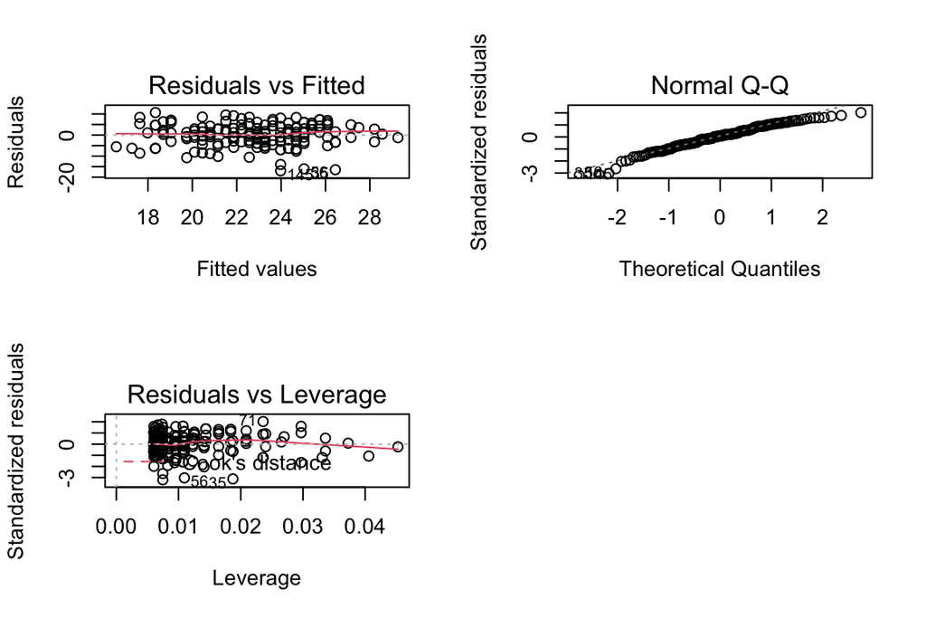

```r
par(mfrow=c(2,2))
plot(linear_regression, which = c(1,2,5))
```

## Chapter 3 alcohol data

```r
date()
```

```
## [1] "Fri Nov 26 13:09:49 2021"
```

```r
library(tidyverse)
data = read.csv('data/alc_data.csv')
print(str(data))
```

```
## 'data.frame':    370 obs. of  35 variables:
##  $ school    : chr  "GP" "GP" "GP" "GP" ...
##  $ sex       : chr  "F" "F" "F" "F" ...
##  $ age       : int  15 15 15 15 15 15 15 15 15 15 ...
##  $ address   : chr  "R" "R" "R" "R" ...
##  $ famsize   : chr  "GT3" "GT3" "GT3" "GT3" ...
##  $ Pstatus   : chr  "T" "T" "T" "T" ...
##  $ Medu      : int  1 1 2 2 3 3 3 2 3 3 ...
##  $ Fedu      : int  1 1 2 4 3 4 4 2 1 3 ...
##  $ Mjob      : chr  "at_home" "other" "at_home" "services" ...
##  $ Fjob      : chr  "other" "other" "other" "health" ...
##  $ reason    : chr  "home" "reputation" "reputation" "course" ...
##  $ guardian  : chr  "mother" "mother" "mother" "mother" ...
##  $ traveltime: int  2 1 1 1 2 1 2 2 2 1 ...
##  $ studytime : int  4 2 1 3 3 3 3 2 4 4 ...
```

[output cut: 22 more lines]

```r
print(max(data$age))
```

```
## [1] 22
```

```r
print( min(data$age))
```

```
## [1] 15
```

The data consists of a questionnaire done to students of ages 15-22. Various questions about their background are asked as well as what they do on their free time, how much alcohol they consume and so forth. Also their grades are given here.

We will choose 4 variables to try to predict alcohol use using those variables. I will choose “failures” since failing a class might indicate alcohol use. In addition “freetime” will be chosen since people who have a lot of free time might be drinking. Age will also be chosen. Finally, I will choose “studytime” since people who study more dont have time to drink.

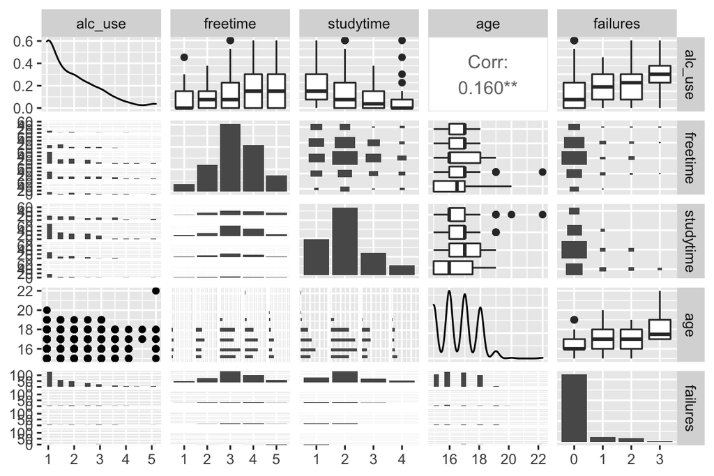

```r
library(GGally)
library(ggplot2)
data$freetime = as.ordered(data$freetime)
data$studytime = as.ordered(data$studytime)
data$failures = as.ordered(data$failures)

data_subset = data[c('alc_use', 'freetime', 'studytime', 'age', 'failures')]

ggpairs(data_subset, mapping = aes(), lower = list(combo = wrap("facethist", bins = 20)))
```

Here we have the relationship between the chosen variables and alcohol use. From the top row we can see that in particular the number of failures correlates with alchohol use: people with 3 failures had the most alcohol use. Age also seems to slightly correlate with alcohol use, with older students drinking more. People who study the most have the least amount of alcohol use. As for freetime, the connection is less clear. Therefore the chosen variables seem to be pretty good at describing alcohol use.

```r
glm_data = data[c('high_use', 'freetime', 'studytime', 'age', 'failures')]
glm_data$failures = ordered(glm_data$failures)
glm_data$age = as.numeric(glm_data$age)
glm_data$studytime = as.ordered(glm_data$studytime)
glm_data$freetime = as.ordered(glm_data$freetime)
glm_model = glm(high_use ~ ., data=glm_data, family = "binomial")
glm_model
```

```
##
## Call:  glm(formula = high_use ~ ., family = "binomial", data = glm_data)
##
## Coefficients:
## (Intercept)   freetime.L   freetime.Q   freetime.C   freetime^4  studytime.L
##    -3.61634      1.13774     -0.37684     -0.01943     -0.16128     -0.98268
## studytime.Q  studytime.C          age   failures.L   failures.Q   failures.C
##     0.37394      0.50550      0.17260      0.79327     -0.17619      0.34081
##
## Degrees of Freedom: 369 Total (i.e. Null);  358 Residual
## Null Deviance:       452
## Residual Deviance: 413.3     AIC: 437.3
```

Here we cast all the features into ordered values except age, since they have a clear ordering (freetime 5 is more than freetime 4)

```r
print(exp(coef(glm_model)))
```

```
## (Intercept)  freetime.L  freetime.Q  freetime.C  freetime^4 studytime.L
##  0.02688092  3.11970354  0.68602398  0.98075575  0.85105503  0.37430663
## studytime.Q studytime.C         age  failures.L  failures.Q  failures.C
##  1.45344515  1.65781273  1.18838494  2.21061040  0.83845977  1.40609193
```

```r
print(confint(glm_model))
```

```
##                   2.5 %      97.5 %
## (Intercept) -7.31978014  0.02252094
## freetime.L   0.15826962  2.40079162
## freetime.Q  -1.45950625  0.47225107
## freetime.C  -0.71317341  0.74441514
## freetime^4  -0.65580945  0.33331230
## studytime.L -1.87775566 -0.23173544
## studytime.Q -0.38618233  1.07809059
## studytime.C -0.08866794  1.15363489
## age         -0.03309116  0.38217471
## failures.L  -0.72327871  2.87497442
## failures.Q  -1.44760231  1.45410711
## failures.C  -0.67903331  1.40836278
```

Since we specified some of the features as having an order, R has fit each variable with a series of polynomial functions (L for linear, Q for quadratic and so on). Lets focus on the linear ones. We can interpret the exponentials of the coefficients as odds ratios for each feature. This means that Failures, for example, has an odds ratio of 2.2/1 meaning it is twice as likely that a person who failed a class uses a high amount of alchohol. Also, freetime seems to have a massive impact on high alcohol use as well, with people who have a lot of freetime being 3 times as likely to use a lot of alcohol. Perhaps somewhat surprisingly age doesnt play a big role.

```r
alc = glm_data
probabilities <- predict(glm_model, type = "response")

# add the predicted probabilities to 'alc'
alc <- mutate(alc, probability = probabilities)

# use the probabilities to make a prediction of high_use
alc <- mutate(alc, prediction = alc$probability > 0.5)

# see the last ten original classes, predicted probabilities, and class predictions
select(alc, failures, age, freetime, studytime, high_use, probability, prediction) %>% tail(10)
```

```
##     failures age freetime studytime high_use probability prediction
## 361        1  18        4         1     TRUE   0.7135619       TRUE
## 362        0  18        3         1     TRUE   0.4044013      FALSE
## 363        0  18        4         1     TRUE   0.5192315       TRUE
## 364        0  18        2         2     TRUE   0.2633834      FALSE
## 365        0  18        3         1    FALSE   0.4044013      FALSE
## 366        0  18        3         1     TRUE   0.4044013      FALSE
## 367        0  18        2         3    FALSE   0.1046941      FALSE
## 368        1  19        4         1     TRUE   0.7475035       TRUE
## 369        2  19        4         2     TRUE   0.6505777       TRUE
## 370        1  19        3         1    FALSE   0.6504956       TRUE
```

```r
# tabulate the target variable versus the predictions
table(high_use = alc$high_use, prediction = alc$prediction)
```

```
##         prediction
## high_use FALSE TRUE
##    FALSE   244   15
##    TRUE     93   18
```

We can see from the matrix that we predicted a TRUE value 18 times when it was actually true, and 15 times when it was actually false. On the other hand, we predicted false 244 times for false samples and 93 times for true samples. This indicates that the model is not very good, but still decent. The training error can be calculated

```r
c_mat = table(high_use = alc$high_use, prediction = alc$prediction)
print('accuracy')
```

```
## [1] "accuracy"
```

```r
print(1 - (c_mat[1, 2] + c_mat[2, 1]) / sum(c_mat))
```

```
## [1] 0.7081081
```

```r
print('majority class')
```

```
## [1] "majority class"
```

```r
print(mean(glm_data$high_use))
```

```
## [1] 0.3
```

Always guessing “False” would get 0.7 accuracy so we are barely better than that. I guess the model is bad after all.

# Boston housing clustering

```r
date()
```

```
## [1] "Fri Nov 26 13:09:56 2021"
```

```r
library(MASS)
data = Boston
str(data)
```

```
## 'data.frame':    506 obs. of  14 variables:
##  $ crim   : num  0.00632 0.02731 0.02729 0.03237 0.06905 ...
##  $ zn     : num  18 0 0 0 0 0 12.5 12.5 12.5 12.5 ...
##  $ indus  : num  2.31 7.07 7.07 2.18 2.18 2.18 7.87 7.87 7.87 7.87 ...
##  $ chas   : int  0 0 0 0 0 0 0 0 0 0 ...
##  $ nox    : num  0.538 0.469 0.469 0.458 0.458 0.458 0.524 0.524 0.524 0.524 ...
##  $ rm     : num  6.58 6.42 7.18 7 7.15 ...
##  $ age    : num  65.2 78.9 61.1 45.8 54.2 58.7 66.6 96.1 100 85.9 ...
##  $ dis    : num  4.09 4.97 4.97 6.06 6.06 ...
##  $ rad    : int  1 2 2 3 3 3 5 5 5 5 ...
##  $ tax    : num  296 242 242 222 222 222 311 311 311 311 ...
##  $ ptratio: num  15.3 17.8 17.8 18.7 18.7 18.7 15.2 15.2 15.2 15.2 ...
##  $ black  : num  397 397 393 395 397 ...
##  $ lstat  : num  4.98 9.14 4.03 2.94 5.33 ...
##  $ medv   : num  24 21.6 34.7 33.4 36.2 28.7 22.9 27.1 16.5 18.9 ...
```

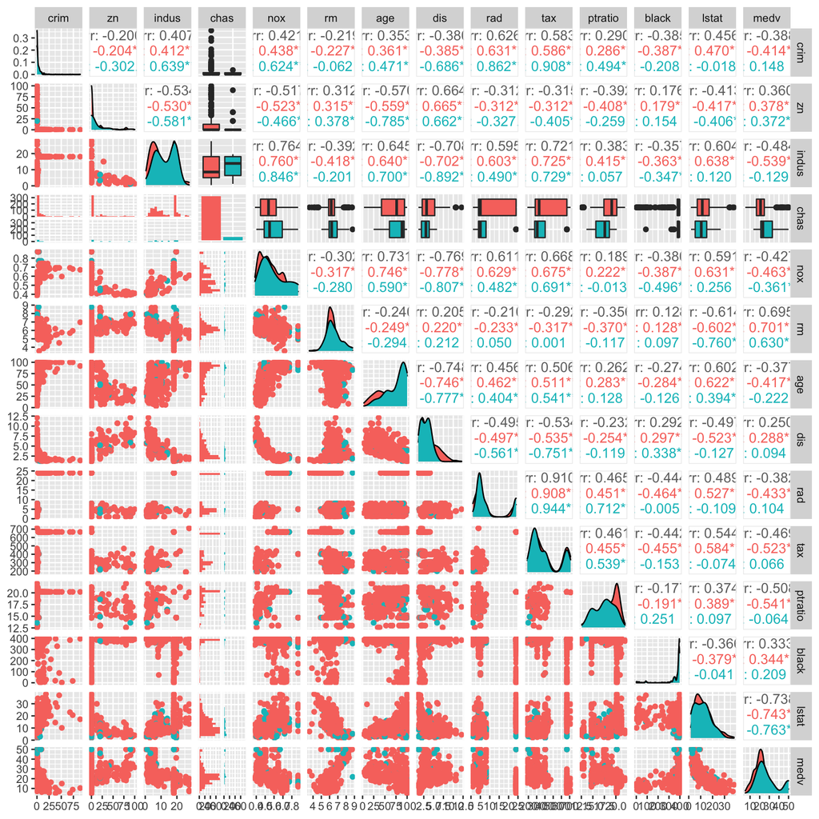

```r
library(GGally)
library(ggplot2)

data$chas = as.factor(data$chas)
ggpairs(data, mapping = aes(colour=chas), lower = list(combo = wrap("facethist", bins = 20)))
```

```r
library(dplyr)
colnames(data)
```

```
##  [1] "crim"    "zn"      "indus"   "chas"    "nox"     "rm"      "age"
##  [8] "dis"     "rad"     "tax"     "ptratio" "black"   "lstat"   "medv"
```

```r
boston_scaled <- data %>% mutate_at(c("crim",    "zn" ,     "indus"  , "nox"    , "rm"   ,   "age"  ,   "dis" ,    "rad"   ,  "tax" ,    "ptratio" ,"black"  , "lstat",  "medv"), ~(scale(.) %>% as.vector))
str(boston_scaled)
```

```
## 'data.frame':    506 obs. of  14 variables:
##  $ crim   : num  -0.419 -0.417 -0.417 -0.416 -0.412 ...
##  $ zn     : num  0.285 -0.487 -0.487 -0.487 -0.487 ...
##  $ indus  : num  -1.287 -0.593 -0.593 -1.306 -1.306 ...
##  $ chas   : Factor w/ 2 levels "0","1": 1 1 1 1 1 1 1 1 1 1 ...
##  $ nox    : num  -0.144 -0.74 -0.74 -0.834 -0.834 ...
##  $ rm     : num  0.413 0.194 1.281 1.015 1.227 ...
##  $ age    : num  -0.12 0.367 -0.266 -0.809 -0.511 ...
##  $ dis    : num  0.14 0.557 0.557 1.077 1.077 ...
##  $ rad    : num  -0.982 -0.867 -0.867 -0.752 -0.752 ...
##  $ tax    : num  -0.666 -0.986 -0.986 -1.105 -1.105 ...
##  $ ptratio: num  -1.458 -0.303 -0.303 0.113 0.113 ...
##  $ black  : num  0.441 0.441 0.396 0.416 0.441 ...
##  $ lstat  : num  -1.074 -0.492 -1.208 -1.36 -1.025 ...
##  $ medv   : num  0.16 -0.101 1.323 1.182 1.486 ...
```

Here we did not scale the variable chas since its binary. Scaling the proportional values also seems odd but I did it anyway since the instructions asked. Now lets create the factor variable

```r
# create a quantile vector of crim and print it
bins <- quantile(boston_scaled$crim)
bins
```

```
##           0%          25%          50%          75%         100%
## -0.419366929 -0.410563278 -0.390280295  0.007389247  9.924109610
```

```r
# create a categorical variable 'crime'
crime <- cut(boston_scaled$crim, breaks = bins, include.lowest = TRUE)

# look at the table of the new factor crime


# remove original crim from the dataset
boston_scaled <- dplyr::select(boston_scaled, -crim)

# add the new categorical value to scaled data
boston_scaled <- data.frame(boston_scaled, crime)
```

```r
str(boston_scaled$crime)
```

```
##  Factor w/ 4 levels "[-0.419,-0.411]",..: 1 1 1 1 1 1 2 2 2 2 ...
```

```r
## 75% of the sample size
smp_size <- floor(0.8 * nrow(boston_scaled))

## set the seed to make your partition reproducible
set.seed(123)
train_ind <- sample(seq_len(nrow(boston_scaled)), size = smp_size)

train <- boston_scaled[train_ind, ]
test <- boston_scaled[-train_ind, ]
print(nrow(train))
```

```
## [1] 404
```

```r
print(nrow(test))
```

```
## [1] 102
```

Now we have partitioned the data into training and test sets. Next lets fit LDA

```r
# linear discriminant analysis
lda.fit <- lda(crime ~ ., data = train)

# print the lda.fit object
lda.fit
```

```
## Call:
## lda(crime ~ ., data = train)
##
## Prior probabilities of groups:
## [-0.419,-0.411]  (-0.411,-0.39] (-0.39,0.00739]  (0.00739,9.92]
##       0.2549505       0.2500000       0.2500000       0.2450495
##
## Group means:
##                          zn      indus      chas1        nox          rm
## [-0.419,-0.411]  1.01866313 -0.9066422 0.04854369 -0.8835724  0.38666334
## (-0.411,-0.39]  -0.07141687 -0.3429155 0.07920792 -0.5768545 -0.09882533
## (-0.39,0.00739] -0.40148591  0.2162741 0.11881188  0.3637157  0.12480815
## (0.00739,9.92]  -0.48724019  1.0149946 0.06060606  1.0481437 -0.47733231
##                        age        dis        rad        tax    ptratio
## [-0.419,-0.411] -0.9213895  0.9094324 -0.6819317 -0.7458486 -0.4234280
## (-0.411,-0.39]  -0.3254849  0.3694282 -0.5395408 -0.4205644 -0.1079710
## (-0.39,0.00739]  0.4564260 -0.3720478 -0.4349280 -0.3191090 -0.2716959
## (0.00739,9.92]   0.8274496 -0.8601246  1.6596029  1.5294129  0.8057784
##                      black        lstat        medv
## [-0.419,-0.411]  0.3729083 -0.766883775  0.47009410
## (-0.411,-0.39]   0.3103406 -0.164921798  0.01548761
## (-0.39,0.00739]  0.1049654  0.009720124  0.19440747
## (0.00739,9.92]  -0.6383964  0.900379309 -0.71294711
##
## Coefficients of linear discriminants:
##                  LD1         LD2        LD3
## zn       0.148390645  0.74870532 -1.0874785
## indus    0.040971465 -0.38126652 -0.1619456
## chas1    0.009688321  0.15606070  0.6690362
## nox      0.312458150 -0.67564471 -1.3104018
## rm       0.011086947 -0.16058718 -0.1572603
## age      0.283482486 -0.38817624 -0.1013491
## dis     -0.079848789 -0.38493775  0.2108038
## rad      3.718978412  0.93123532 -0.4706522
## tax     -0.015197127  0.04230505  1.2889075
## ptratio  0.180294774 -0.01592588 -0.3558490
## black   -0.136724112  0.02948075  0.1288959
## lstat    0.145739238 -0.37823065  0.3345688
## medv     0.061327205 -0.53906503 -0.1509890
##
## Proportion of trace:
##    LD1    LD2    LD3
## 0.9523 0.0364 0.0113
```

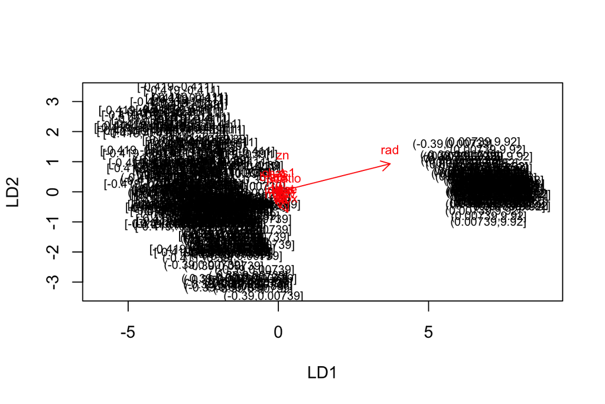

```r
# the function for lda biplot arrows
lda.arrows <- function(x, myscale = 1, arrow_heads = 0.1, color = "red", tex = 0.75, choices = c(1,2)){
  heads <- coef(x)
  arrows(x0 = 0, y0 = 0,
         x1 = myscale * heads[,choices[1]],
         y1 = myscale * heads[,choices[2]], col=color, length = arrow_heads)
  text(myscale * heads[,choices], labels = row.names(heads),
       cex = tex, col=color, pos=3)
}

# target classes as numeric
classes <- as.numeric(train$crime)

# plot the lda results
plot(lda.fit, dimen = 2)
lda.arrows(lda.fit, myscale = 1)
```

I didn’t really understand the plot but lets move on. Next we will predict using LDA on the test set

```r
true_crime = test$crime
test <- dplyr::select(test, -crime)
# predict classes with test data
lda.pred <- predict(lda.fit, newdata = test)

# cross tabulate the results
table(correct = true_crime, predicted = lda.pred$class)
```

```
##                  predicted
## correct           [-0.419,-0.411] (-0.411,-0.39] (-0.39,0.00739] (0.00739,9.92]
##   [-0.419,-0.411]              10             10               4              0
##   (-0.411,-0.39]                2             17               6              0
##   (-0.39,0.00739]               1              9              13              2
##   (0.00739,9.92]                0              0               1             27
```

The different quantiles indicate different crime rates, with [-0.419,-0.411] being the smallest bin and (0.00739,9.92] being the highest one. We predicted the high crime areas very well, since only 1 was incorrectly classified when the true class was the highest crime rate. On the other hand in the smaller crime rates there are more mistakes which indicates they are not as easy to classify. Now lets reload boston dataset to run k-means

```r
boston_scaled <- data %>% mutate_at(c("crim",    "zn" ,     "indus"  , "nox"    , "rm"   ,   "age"  ,   "dis" ,    "rad"   ,  "tax" ,    "ptratio" ,"black"  , "lstat",  "medv"), ~(scale(.) %>% as.vector))
```

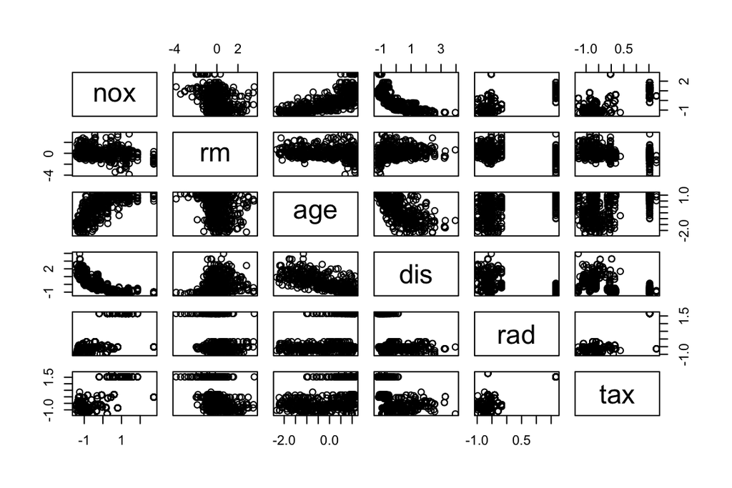

```r
# k-means clustering
km <-kmeans(boston_scaled, centers = 1)

# plot the Boston dataset with clusters
pairs(boston_scaled[5:10], col = km$cluster)
```

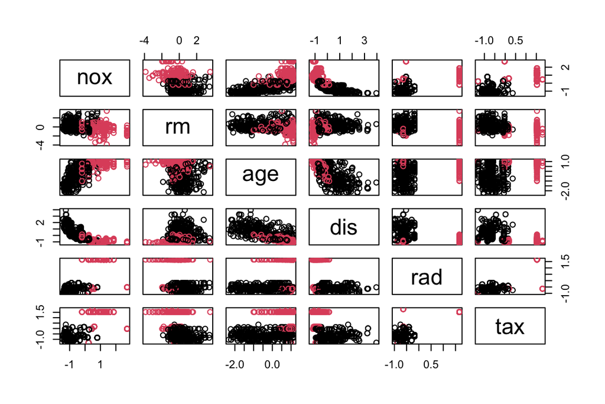

```r
# k-means clustering
km <-kmeans(boston_scaled, centers = 2)

# plot the Boston dataset with clusters
pairs(boston_scaled[5:10], col = km$cluster)
```

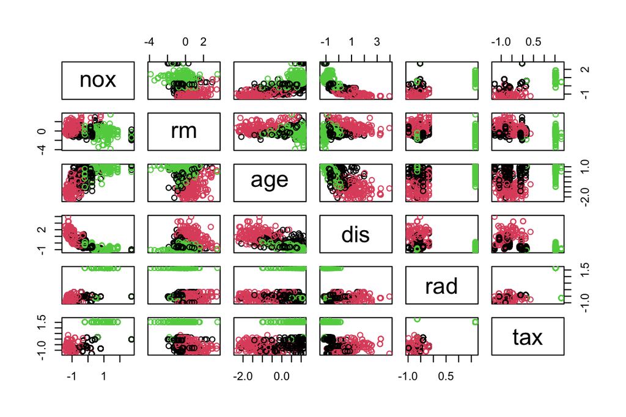

```r
# k-means clustering
km <-kmeans(boston_scaled, centers = 3)

# plot the Boston dataset with clusters
pairs(boston_scaled[5:10], col = km$cluster)
```

Here we saw three different amounts of clusters. Clearly 1 cluster is not useful, but two seems to partition the data nicely in most cases. Three tends to just partition a fairly uniform group into two separate groups which does not feel useful. So here I would argue 2 is a good choice.

Regarding the clustering itself we can see that for example there are two clear clusters in the nox / tax plot which indicates that there is a set of outlier tax rates which are more or less the same.

(more chapters to be added similarly as we proceed with the course!)